# Demo 1 Spotify

Astete, Gálvez, González

24-10-2020

## Introducción

### Contextualización y planteamiento del problema de investigación

Esta investigación describe las preferencias musicales de chilenos/as que usan la plataforma digital de música Spotify, en términos de Danceability y Energy. Para ello se utilizó la base de datos de la lista “Top 50 Chile” de las canciones más escuchadas el 24 de octubre del 2020.

A nivel global las plataformas de música en streaming han aumentado su público auditor, Chile no es la excepción. Desde la pandemia por coronavirus Spotify aumentó en un 31% sus usuarios(Rock&Pop, 2020).

De los servicios disponibles en Chile, Spotify es el más popular. Tiene un 28% de las preferencias. En términos globales, Spotify también lidera las preferencias, con 50 millones de suscriptores contra 27 de la aplicación de Apple. Además, la aplicación en su versión gratuita se ha posicionado en el segundo lugar de las preferencias de quienes escuchan contenido online, en todos los segmentos de edad, compitiendo con las radios en línea. Esto se refleja en su reconocimiento de marca, alcanzando un 79% entre los chilenos, principalmente usuarios de entre 15 y 34 años (Aguirre, 2017; Bertollini, P. Cabrera, F. & Ovalle, M., 2019 ).

Las canciones de la lista “top 50”, son las que se muestran a continuación:

```
## [[1]]
##  [1] "Dakiti"
##  [2] "PAPI JUANCHO"
##  [3] "ENOC"
##  [4] "La Tóxica"
##  [5] "Jeans"
##  [6] "Relación (Remix)"
##  [7] "La Nota"
##  [8] "Platonicos"
##  [9] "Ay, DiOs Mío!"
## [10] "Vida de Rico"
## [11] "Mi Niña"
## [12] "Tattoo (Remix with Camilo)"
## [13] "Now Or Never"
## [14] "Chica Ideal"
```

[output cut: 36 more lines]

#### Efectos Psicológicos de la música

Según el campo de estudio de la influencia de la música en las personas, la música puede tanto representar las emociones de las personas como inducirlas en ellas(Gomez & Danuser, 2007; en Caballero &Menez, 2010). Y el contexto social , político y económico influye en las emociones que las personas puedan sentir(estrés, angustia , entre otras), sobretodo en las personas entre 18 y 30 años y en las mayores de 60(Huarcaya,2020). Por lo que habría una relación entre la música que se escucha y el contexto social en Chile hasta el 24 de Octubre.

#### Crisis Social y Política

En primer lugar, a partir del 18 de octubre del 2019 se han vivido en Chile fuertes protestas en distintos puntos del país para expresar un descontento social generalizado con la clase política y para exigir demandas en torno a derechos sociales como pensiones, salud y educación(Herranz, 2019; Mira, 2012 ). Bajo este contexto es que se llega al plebiscito del 25 de octubre del 2020 para decidir si se hará una nueva constitución para el país. Este plebiscito figura como un hecho histórico, ya que es primera vez que se abre la posibilidad de cambiar la constitución de 1980 la cual fue redactada durante la dictadura militar.

#### Sanitaria y Económica

A esta crisis política y social se suma a principios de 2020 una crisis sanitaria mundial por la propagación del virus Sars-Cov-2, popularmente conocido como COVID-19 o coronavirus. Esta crisis sanitaria, catalogada como pandemia trajo varias consecuencias, dentro de las cuales está el desempleo, la precariedad laboral (Atria, Grau, Inostroza, Joignant, Madariaga & Sanhueza, 2020), el aumento de la pobreza y manifestaciones por el hambre vivida en distintas comunas (BBC,2020).

## Pregunta de investigación

Bajo este escenario nacional se busca conocer ¿Cómo son las preferencias musicales de los/as chilenos/as en Spotify el 24 de Octubre del año 2020?

## Metodología

Los datos fueron obtenidos el 24 de Octubre a través de una Interfaz de programación de aplicaciones (API, por sus siglas en inglés) desde la plataforma de Spotify para desarrolladores. Se procesó una base con los nombres de las 50 canciones más escuchadas y sus niveles de danceability y energy.

En primer lugar, Danceability es una variable que mide la capacidad de baile de una canción y describe qué tan adecuada es una pista para bailar en función de una combinación de elementos musicales que incluyen el tempo, la estabilidad del ritmo, la fuerza del ritmo y la regularidad general. Un valor de 0.0 es menos bailable y 1.0 es más bailable.

En segundo lugar, Energy, variable que toma valores entre 0.0 y 1.0 y representa una medida perceptiva de intensidad y actividad. Por lo general, las pistas enérgicas se sienten rápidas, ruidosas y ruidosas. Las características de percepción que contribuyen a este atributo incluyen rango dinámico, volumen percibido, timbre, frecuencia de inicio y entropía general.

## Desarrollo

En este apartado se presentará el procesamiento de los datos recabados

### Tabla de estadísticos descriptivos

|  | V1 | V2 | V3 | V4 | V5 | V6 |
| --- | --- | --- | --- | --- | --- | --- |
| nombres | Mínimo | Q1 | Media | Desviación Estándar | Q3 | Máximo |
| descriptivos_danceability | 0.483 | 0.699 | 0.74722 | 0.0920269015682094 | 0.81225 | 0.905 |
| descriptivos_energy | 0.457 | 0.63325 | 0.70136 | 0.107735079463185 | 0.77425 | 0.891 |

En cuanto a “energy” los valores de los 50 datos van desde 0,457 a 0,891, en una escala de 0,0 a 1,0. Se puede decir que el 25 % de los datos tienen valores desde 0,457 a 0,633, por lo que un 75% de los datos esta sobre este numero. Se puede decir que las canciones tienen un alto nivel de “energy” ya que la mayoría se encuentra sobre el 0,5(se encuentran sobre la mitad de la escala de medición de la variable). Solo un 25% de los datos tienen un valor sobre 0,774. En cuanto al promedio es de 0,701 y la desviación estándar es de 0,107. La desviación estándar es pequeña, por lo que se puede decir que los datos no están muy dispersos, lo que permitiría decir que el promedio es significativo.

### Gráficos:

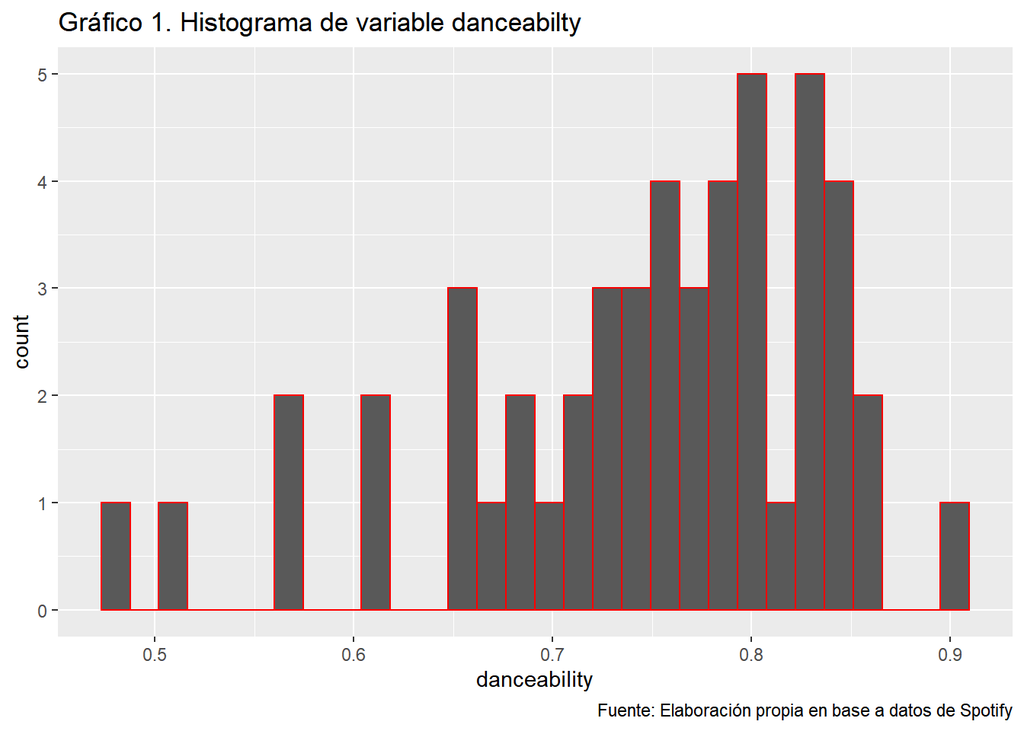

El gráfico 1 muestra un histograma de los valores de la variable “danceability”. Como fue mencionado anteriormente esta variable tiene una media de 0.746, además la variable tiene una mediana de:

```
## [1] 0.7635
```

Siendo la media levemente menor que la mediana se puede mencionar que existe una leve tendencia de los datos hacia los mayores valores de la distribución.

Esto se puede corroborar calculando la simetría de la distribución, la cual es:

```
## [1] -0.9344101
```

Siendo esta negativa se puede corroborar que los valores de la variable danceability tienden hacia los valores más altos de la distribución.

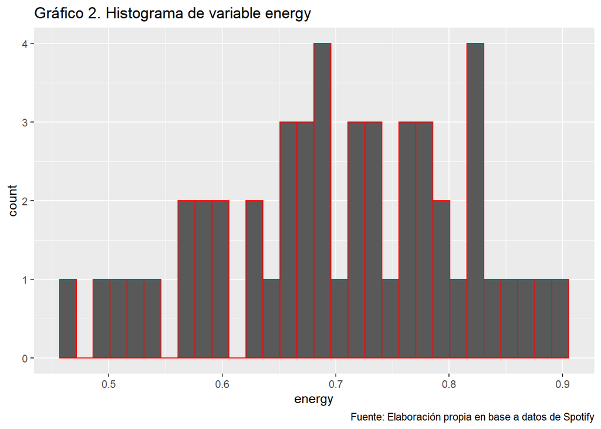

El gráfico 2 muestra un histograma de los valores de la variable “energy”.Esta variable tiene una media de 0.701, además la variable tiene una mediana de:

```
## [1] 0.7065
```

Dados estos valores, se observa entonces que la media, al igual que con la variable anterior, es levemente menor que la mediana. Dado esto se puede afirmar que también existe una leve tendencia de los datos hacia los mayores valores de la distribución.

La simetría de la distribución es:

```
## [1] -0.2788487
```

Siendo esta negativa se puede corroborar que los valores de la variable energy tienden hacia los valores más altos de la distribución.

## Conclusiones

Dado el análisis realizado a los datos obtenidos a partir de la lista de las 50 canciones más escuchadas en Chile de Spotify, es posible plantear que las canciones más escuchadas tienden a tener altos valores en los indicadores de energy y danceability. Por lo que se puede decir que las canciones más consumidas o escuchadas por chilenos el 24 de Octubre, tienden a ser música que es bailable, estimulante y energizante.

Para una futura investigación que pretenda seguir la idea planteada, es necesario mencionar que para poder sacar conclusiones societales a partir de los usuarios de Spotify. Se necesitaría una caracterización exhaustiva de estos grupos, para poder extrapolar conclusiones al resto de la población.

## Bibliografia

Aguirre, F. (2017). Usuarios chilenos de Spotify escuchan 52 millones de canciones a la semana. La Tercera. https://www.latercera.com/noticia/usuarios-chilenos-spotify-escuchan-52-millones-canciones-la-semana/

Atria. J, Grau.N, Inostroza.V, Joignant.A, Madariaga.A & Sanhueza.C. (2020). La política económica frente al COVID-19 en Chile y el mundo: una invitación a ampliar las fronteras de lo posible. Santiago, Region Metropoitana, Chile.Recuperado: https://ciperchile.cl/2020/05/24/la-politica-economica-frente-al-covid-19-en-chile-y-el-mundo-una-invitacion-a-ampliar-las-fronteras-de-lo-posible/

BBC . (2020). Coronavirus en Chile: las imágenes de las protestas en Santiago por la difícil situación económica creada en Chile por la pandemia de covid-19. Londres, Gran Londres, Inglaterra.Recuperado: https://www.bbc.com/mundo/noticias-america-latina-52717413

Bertollini, P. Cabrera, F. & Ovalle, M. (2019). Spotify y el impacto de las plataformas de streaming musical. Medium. https://medium.com/@streamusic12/spotify-y-el-impacto-de-las-plataformas-de-streaming-musical-ccc2f8016527

Caballero-Meneses, J. A., & Menez, M. (2010). Influencia del tempo de la música en las emociones. Revista colombiana de psicología, 19(1), 37-44. Huarcaya-Victoria, J. (2020). Consideraciones sobre la salud mental en la pandemia de COVID-19. Revista Peruana de Medicina Experimental y Salud Pública, 37(2).

Herranz, M. (2019). Los 10 hechos que resumen el mes de la crisis social en Chile. Obtenido de emol: https://www.emol.com/noticias/Nacional/2019/11/18/967500/10-hechos-resumen-crisis-social.html

Mira, A. (2012). Crisis de representatividad y estallido social . Polis [En línea], Publicado el 04 abril 2012, consultado el 30 Octubre 2020. URL : http://journals.openedition.org/polis/2232

Spotify: Usuarios aumentan un 31% desde inicio de la pandemia. (2020). Rock&Pop. https://www.rockandpop.cl/2020/04/spotify-usuarios-aumentan-un-31-desde-inicio-de-la-pandemia/